# Actividad 2.1. Regresión lineal simple: Método de mínimos cuadrados

Raúl Correa Ocañas

2024-08-07

# 0. Importación de los Datos

```r
df <- read.csv(r"(..\data\mc-donalds-menu.csv)")
df <- data.frame(df)
```

# 1. Análisis Exploratorio

```r
head(df, n = 3)
```

```
##    Category              Item   Serving.Size Calories Calories.from.Fat
## 1 Breakfast      Egg McMuffin 4.8 oz (136 g)      300               120
## 2 Breakfast Egg White Delight 4.8 oz (135 g)      250                70
## 3 Breakfast  Sausage McMuffin 3.9 oz (111 g)      370               200
##   Total.Fat Total.Fat....Daily.Value. Saturated.Fat
## 1        13                        20             5
## 2         8                        12             3
## 3        23                        35             8
##   Saturated.Fat....Daily.Value. Trans.Fat Cholesterol
## 1                            25         0         260
## 2                            15         0          25
## 3                            42         0          45
##   Cholesterol....Daily.Value. Sodium Sodium....Daily.Value. Carbohydrates
## 1                          87    750                     31            31
## 2                           8    770                     32            30
## 3                          15    780                     33            29
##   Carbohydrates....Daily.Value. Dietary.Fiber Dietary.Fiber....Daily.Value.
## 1                            10             4                            17
## 2                            10             4                            17
## 3                            10             4                            17
##   Sugars Protein Vitamin.A....Daily.Value. Vitamin.C....Daily.Value.
## 1      3      17                        10                         0
## 2      3      18                         6                         0
## 3      2      14                         8                         0
##   Calcium....Daily.Value. Iron....Daily.Value.
## 1                      25                   15
## 2                      25                    8
## 3                      25                   10
```

```r
names(df)
```

```
##  [1] "Category"                      "Item"
##  [3] "Serving.Size"                  "Calories"
##  [5] "Calories.from.Fat"             "Total.Fat"
##  [7] "Total.Fat....Daily.Value."     "Saturated.Fat"
##  [9] "Saturated.Fat....Daily.Value." "Trans.Fat"
## [11] "Cholesterol"                   "Cholesterol....Daily.Value."
## [13] "Sodium"                        "Sodium....Daily.Value."
## [15] "Carbohydrates"                 "Carbohydrates....Daily.Value."
## [17] "Dietary.Fiber"                 "Dietary.Fiber....Daily.Value."
## [19] "Sugars"                        "Protein"
## [21] "Vitamin.A....Daily.Value."     "Vitamin.C....Daily.Value."
## [23] "Calcium....Daily.Value."       "Iron....Daily.Value."
```

```r
summary(df$Protein)
```

```
##    Min. 1st Qu.  Median    Mean 3rd Qu.    Max.
##    0.00    4.00   12.00   13.34   19.00   87.00
```

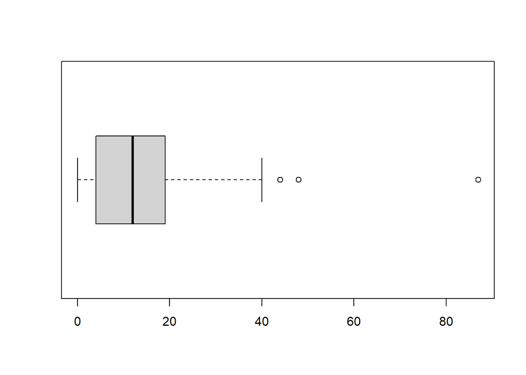

```r
boxplot(df$Protein, horizontal = TRUE)
```

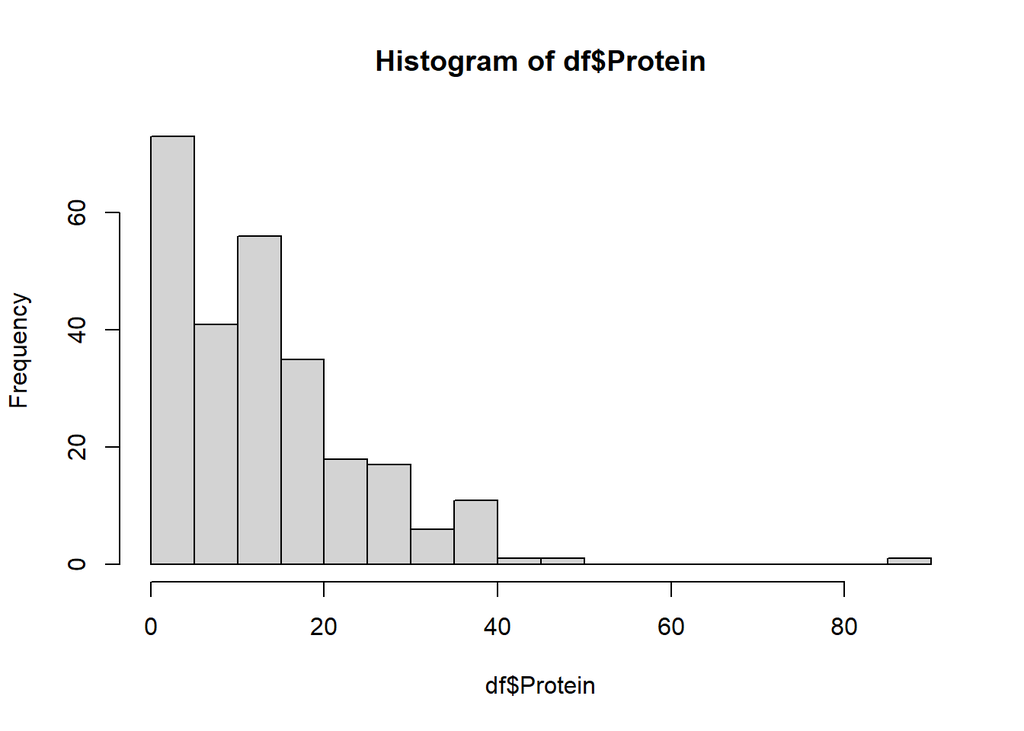

```r
hist(df$Protein, breaks = seq(from=min(df$Protein), to=max(df$Protein)+5, by=5))
```

```r
library(dplyr)
numeric_vars <- select_if(df, is.numeric)

cov_df <- data.frame(cov(numeric_vars, df$Protein))
cor_df <- data.frame(cor(numeric_vars, df$Protein))

cov_df
```

```
##                               cov.numeric_vars..df.Protein.
## Calories                                        2162.923968
## Calories.from.Fat                               1180.465399
## Total.Fat                                        131.117553
## Total.Fat....Daily.Value.                        202.031838
## Saturated.Fat                                     36.669201
## Saturated.Fat....Daily.Value.                    184.633383
## Trans.Fat                                          1.903713
## Cholesterol                                      559.961687
## Cholesterol....Daily.Value.                      186.465162
## Sodium                                          5734.764479
## Sodium....Daily.Value.                           238.889694
## Carbohydrates                                    113.670033
## Carbohydrates....Daily.Value.                     37.904604
## Dietary.Fiber                                     11.488387
## Dietary.Fiber....Daily.Value.                     47.321592
## Sugars                                           -58.966142
## Protein                                          130.556816
## Vitamin.A....Daily.Value.                         59.607841
## Vitamin.C....Daily.Value.                        -13.780101
## Calcium....Daily.Value.                           63.781348
## Iron....Daily.Value.                              79.012949
```

```r
cor_df
```

```
##                               cor.numeric_vars..df.Protein.
## Calories                                         0.78784745
## Calories.from.Fat                                0.80791326
## Total.Fat                                        0.80777296
## Total.Fat....Daily.Value.                        0.80792221
## Saturated.Fat                                    0.60302754
## Saturated.Fat....Daily.Value.                    0.60658146
## Trans.Fat                                        0.38824850
## Cholesterol                                      0.56156141
## Cholesterol....Daily.Value.                      0.56095695
## Sodium                                           0.86980157
## Sodium....Daily.Value.                           0.86986999
## Carbohydrates                                    0.35212224
## Carbohydrates....Daily.Value.                    0.35217806
## Dietary.Fiber                                    0.64134483
## Dietary.Fiber....Daily.Value.                    0.65664825
## Sugars                                          -0.17993965
## Protein                                          1.00000000
## Vitamin.A....Daily.Value.                        0.21409799
## Vitamin.C....Daily.Value.                       -0.04577681
## Calcium....Daily.Value.                          0.32797109
## Iron....Daily.Value.                             0.79271946
```

Candidatos basandose en Coeficiente de Correlación:

- Calories
- Calories from Fat
- Total Fat
- Total Fat Daily Value
- Sodium
- Sodium Daily Value

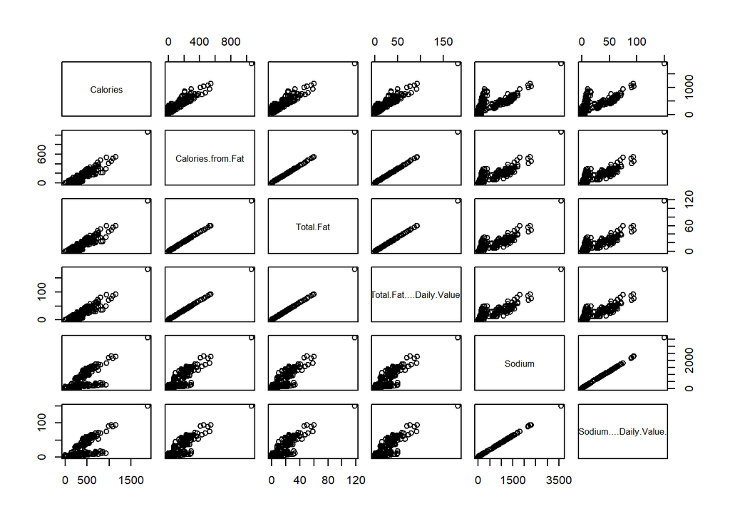

```r
# Interdependencia

pairs(x = df[c("Calories", "Calories.from.Fat", "Total.Fat", "Total.Fat....Daily.Value.", "Sodium", "Sodium....Daily.Value.")])
```

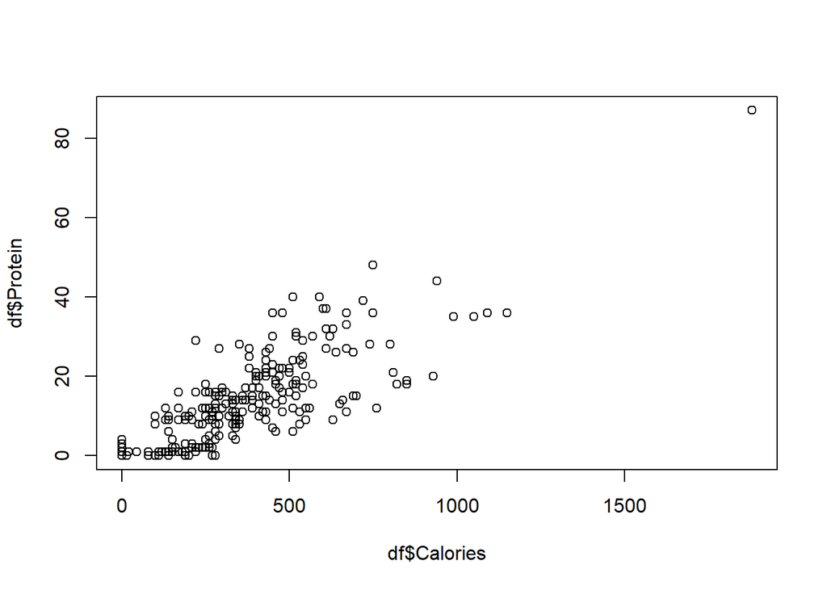

```r
library(ggplot2)
plot(df$Calories, df$Protein)
```

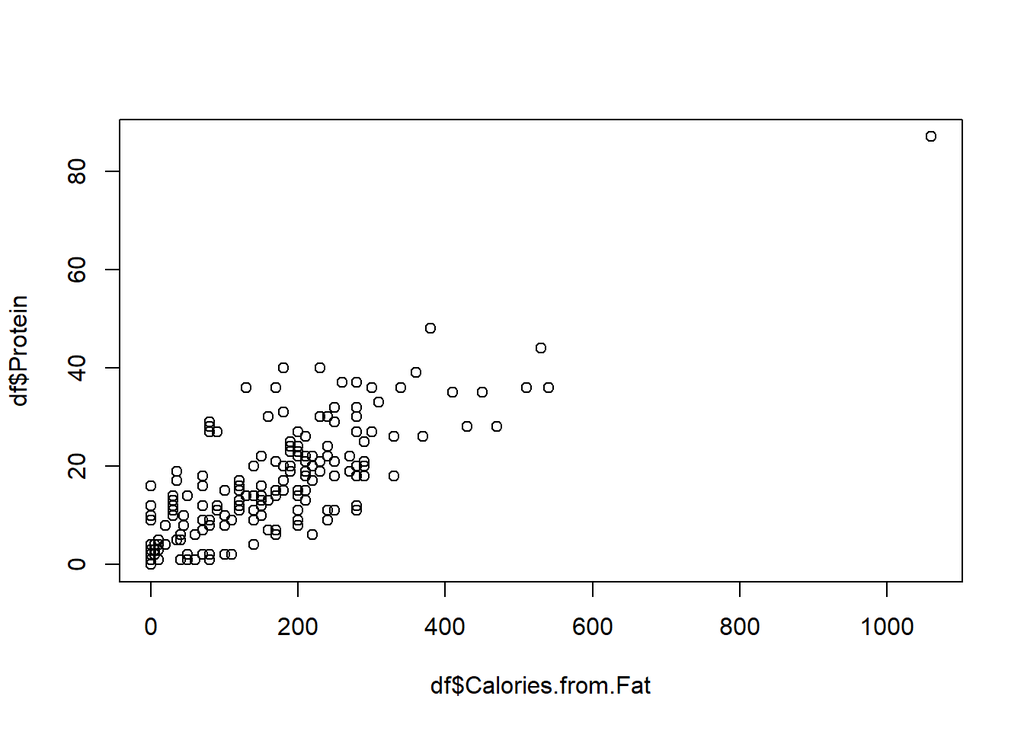

```r
plot(df$Calories.from.Fat, df$Protein)
```

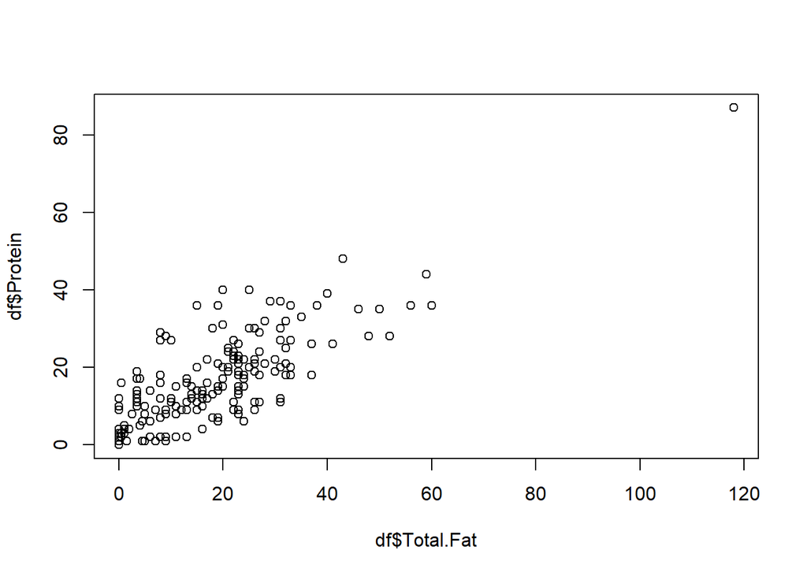

```r
plot(df$Total.Fat, df$Protein)
```

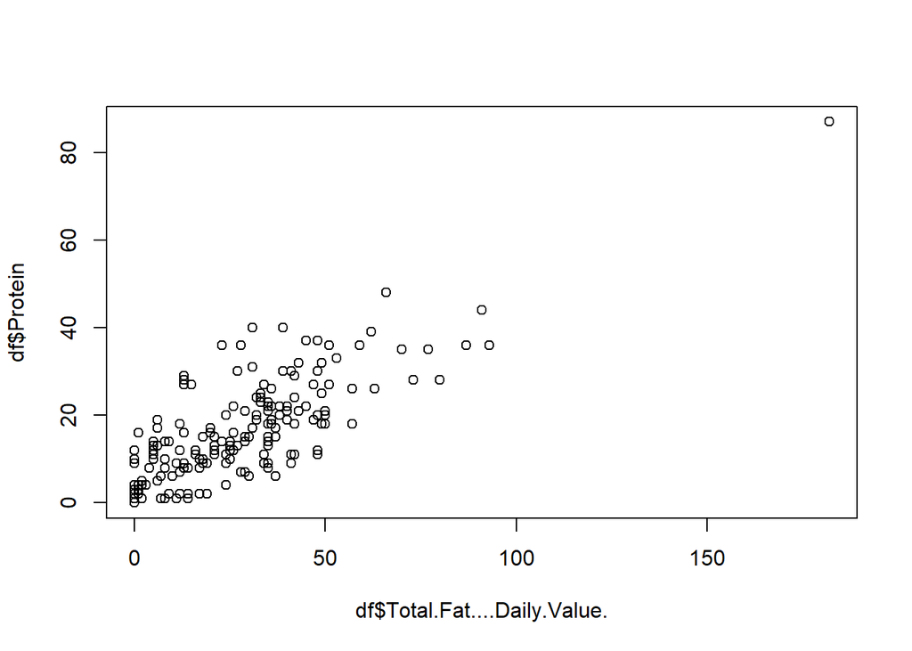

```r
plot(df$Total.Fat....Daily.Value., df$Protein) # descartemos este
```

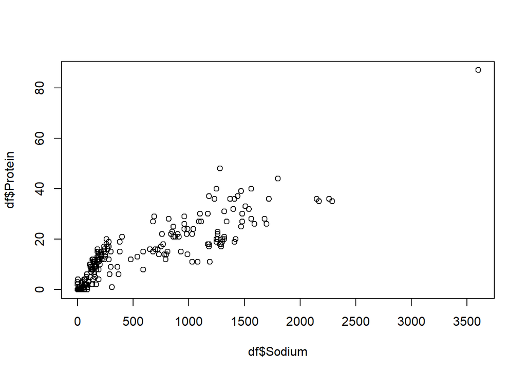

```r
plot(df$Sodium, df$Protein)
```

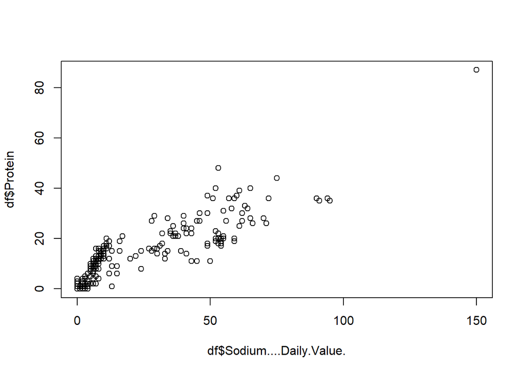

```r
plot(df$Sodium....Daily.Value., df$Protein) # y este tambien
```

# 2. Método de Mínimos Cuadrados

$$\beta = (X^{T}X)^{-1}X^{T}Y$$

```r
X <- cbind(1, df$Total.Fat)

beta <- solve(t(X) %*% X) %*% t(X) %*% df$Protein
beta
```

```
##           [,1]
## [1,] 4.1351165
## [2,] 0.6497067
```

# 3. Regresión lineal en R

```r
ols <- lm(df$Protein ~ df$Sodium)
intercept <- ols$coefficients[1]
b1 <- ols$coefficients[2]

ols
```

```
##
## Call:
## lm(formula = df$Protein ~ df$Sodium)
##
## Coefficients:
## (Intercept)    df$Sodium
##     4.79985      0.01722
```

# 4. Representación Gráfica

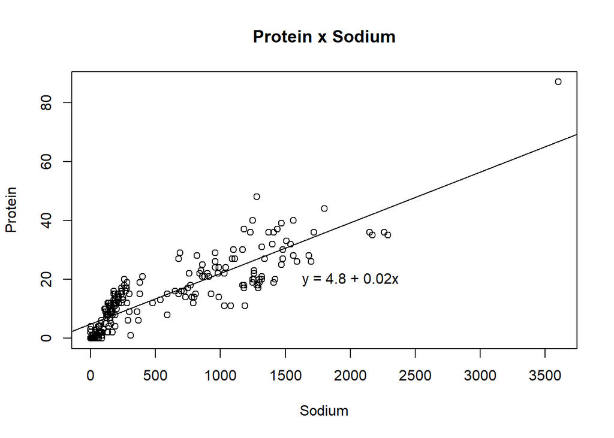

```r
plot(df$Sodium, df$Protein, ylab = "Protein",xlab = "Sodium")
abline(ols)
title("Protein x Sodium")
equation <- paste("y = ", round(intercept, 2), " + ", round(b1, 2), "x", sep = "")
text(x = 2000, y = 20, equation,)
```

# 5. Coeficiente de Determinación

```r
summary(ols)
```

```
##
## Call:
## lm(formula = df$Protein ~ df$Sodium)
##
## Residuals:
##      Min       1Q   Median       3Q      Max
## -14.2960  -4.7999  -0.0672   3.7888  21.1539
##
## Coefficients:
##              Estimate Std. Error t value Pr(>|t|)
## (Intercept) 4.7998539  0.4622223   10.38   <2e-16 ***
## df$Sodium   0.0172236  0.0006083   28.32   <2e-16 ***
## ---
## Signif. codes:  0 '***' 0.001 '**' 0.01 '*' 0.05 '.' 0.1 ' ' 1
##
## Residual standard error: 5.649 on 258 degrees of freedom
## Multiple R-squared:  0.7566, Adjusted R-squared:  0.7556
## F-statistic: 801.8 on 1 and 258 DF,  p-value: < 2.2e-16
```

$$R^{2}=1-\frac{RSS}{TSS}$$

El modelo explica el 75.6% de la variabilidad de los datos.

# 6. Validación del Modelo

## 6.1 Linealidad

T Test

- $H_0:=$ El coeficiente es igual a 0.
- $H_A:=$ El coeficiente no es igual a 0.

Significancia de los coeficientes de regresión:

```r
summary(ols)
```

```
##
## Call:
## lm(formula = df$Protein ~ df$Sodium)
##
## Residuals:
##      Min       1Q   Median       3Q      Max
## -14.2960  -4.7999  -0.0672   3.7888  21.1539
##
## Coefficients:
##              Estimate Std. Error t value Pr(>|t|)
## (Intercept) 4.7998539  0.4622223   10.38   <2e-16 ***
## df$Sodium   0.0172236  0.0006083   28.32   <2e-16 ***
## ---
## Signif. codes:  0 '***' 0.001 '**' 0.01 '*' 0.05 '.' 0.1 ' ' 1
##
## Residual standard error: 5.649 on 258 degrees of freedom
## Multiple R-squared:  0.7566, Adjusted R-squared:  0.7556
## F-statistic: 801.8 on 1 and 258 DF,  p-value: < 2.2e-16
```

El resumen indica que la prueba de T regresó valores de 10.38 y 28.32, por lo que los coeficientes del modelo sugerido son significativos. Se rechaza la hipótesis nula, y por lo tanto los coeficientes son diferentes a 0.

## 6.2 Normalidad

T Test

- $H_0:=$ La media de los errores es igual a 0.
- $H_A:=$ La media de los errores no es igual a 0.

Shapiro-Wilk normality test

- $H_0:=$ La distribución de los errores es normal
- $H_A:=$ La distribución de los errores no es normal

```r
t.test(ols$residuals)
```

```
##
##  One Sample t-test
##
## data:  ols$residuals
## t = 1.9846e-16, df = 259, p-value = 1
## alternative hypothesis: true mean is not equal to 0
## 95 percent confidence interval:
##  -0.6884874  0.6884874
## sample estimates:
##    mean of x
## 6.938727e-17
```

```r
shapiro.test(ols$residuals)
```

```
##
##  Shapiro-Wilk normality test
##
## data:  ols$residuals
## W = 0.97274, p-value = 7.061e-05
```

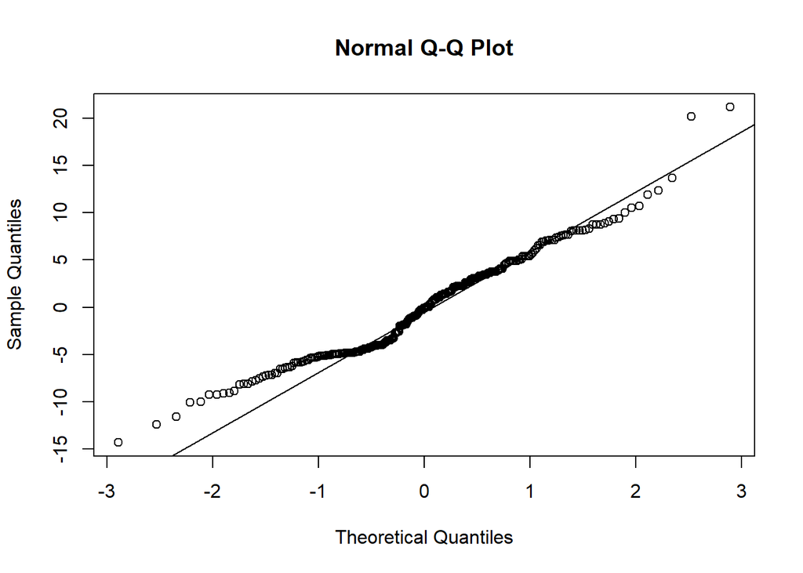

```r
qqnorm(ols$residuals)
qqline(ols$residuals)
```

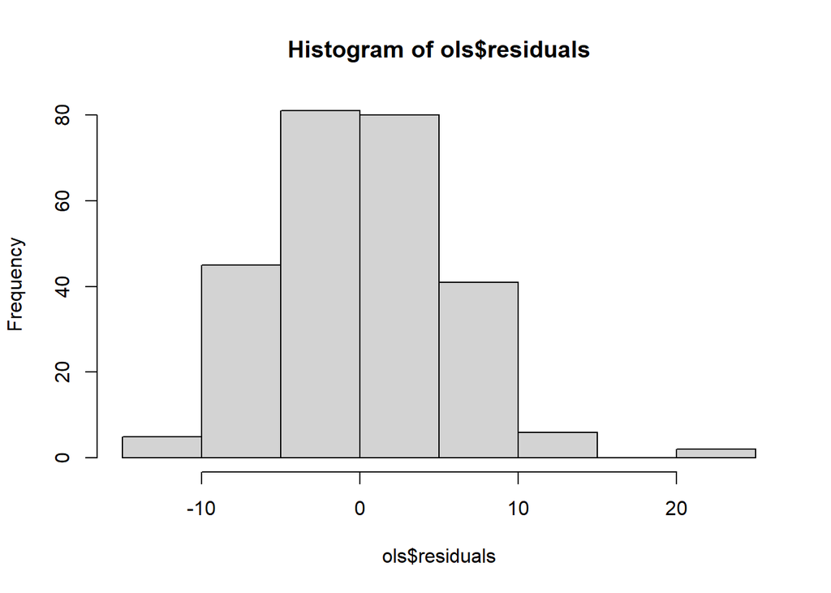

```r
hist(ols$residuals)
```

## 6.3 Homocedasticidad

Breusch-Pagan

- $H_0:=$ Los datos tienen homocedasticidad.
- $H_A:=$ Los datos no tienen homocedasticidad.

```r
library(lmtest)
bptest(ols)
```

```
##
##  studentized Breusch-Pagan test
##
## data:  ols
## BP = 49.05, df = 1, p-value = 2.496e-12
```

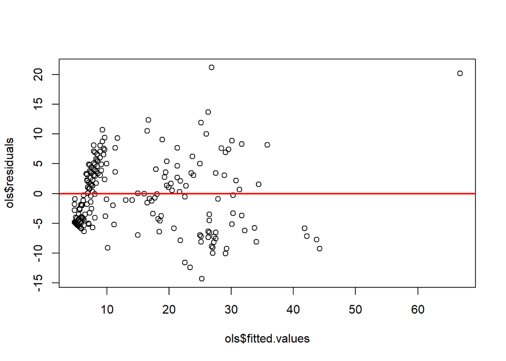

```r
plot(ols$fitted.values, ols$residuals)
abline(h=0, col = "red", lwd = 2)
```

Debido al extremadamente bajo valor de p, se rechaza la hipótesis nula y por ende tampoco se puede asumir que la varianza es constante.

## 6.4 Independencia

Durbin Watson

- $H_0:=$ No existe autocorrelación en los datos
- $H_A:=$ Existe autocorrelacion en los datos.

```r
dwtest(ols)
```

```
##
##  Durbin-Watson test
##
## data:  ols
## DW = 0.62965, p-value < 2.2e-16
## alternative hypothesis: true autocorrelation is greater than 0
```

```r
bptest(ols, varformula = ~ Sodium + I(Sodium^2), data = df)
```

```
##
##  studentized Breusch-Pagan test
##
## data:  ols
## BP = 68.477, df = 2, p-value = 1.35e-15
```

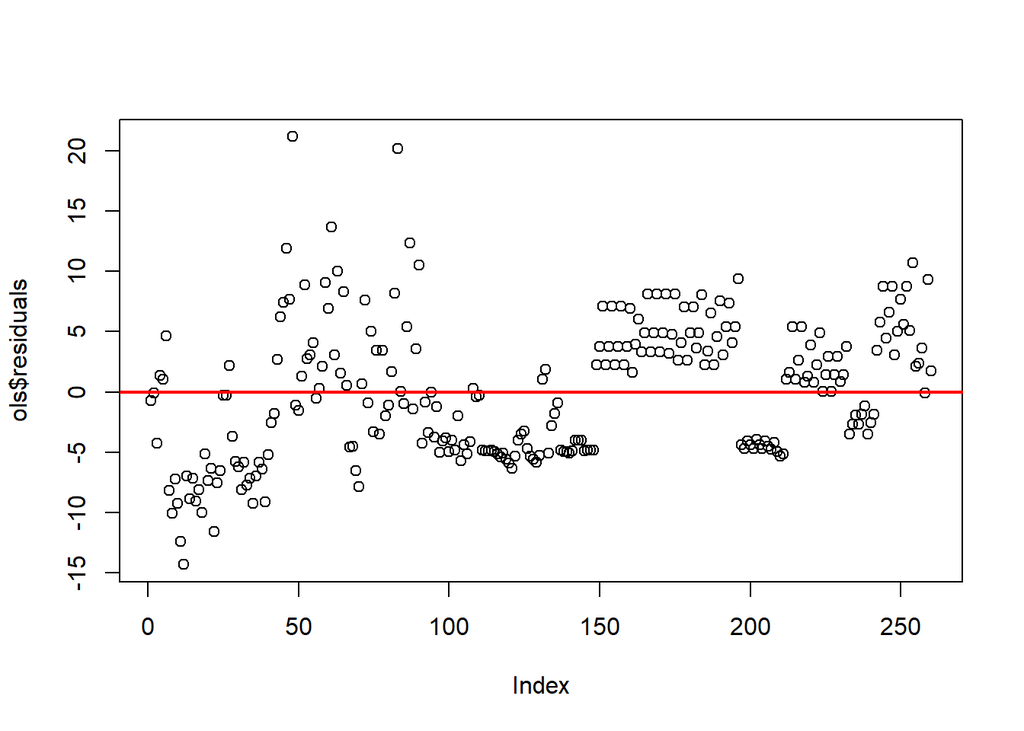

```r
plot(ols$residuals)
abline(h=0, col = "red", lwd = 2)
```

Aunque no hay un patrón claro que pueda describir la varianza, aún así se puede observar una tendencia de oscilación de los residuos. Junto a los resultados, se afirma que existe autocorrelación y por ende no son independientes.

# **7. Conclusiones**

El modelo de regresión lineal entre el sodio y las proteínas en el menú de McDonald’s es significativo y explica el 75.6% de la variabilidad en las proteínas. Sin embargo, las pruebas indican fallos en los supuestos de normalidad, homocedasticidad e independencia de los residuos, sugiriendo que las estimaciones pueden no ser totalmente fiables. Se pueden considerar otros modelos, variables y transformaciones para ajustarse mejor a los datos.